## Phân tích tập dữ liệu và rút ra kết luận về ảnh hưởng của thể loại phim và đánh giá nội dung tới điểm số IMDB

- Nhóm thực hiện:
  - Trần Tiến Đức - 18133007
  - Lương Uy Long - 18133026
  - Lê Đỗ Trà My - 18133030
  - Trần Như Thuận - 18133054
- Thời gian thực hiện: 19-27/1/2021

## Giới thiệu

- Nguồn dữ liệu: https://www.kaggle.com/adnanr94/imdb-movies-metadata
- Phân tích tập dữ liệu và rút ra kết luận về ảnh hưởng của thể loại phim và đánh giá nội dung tới điểm số

## Tổng quan về dữ liệu

- Cấu trúc của tập dữ liệu

```
## 'data.frame':    3756 obs. of  31 variables:
##  $ movie_id                 : int  1 2 3 4 6 7 8 9 10 11 ...
##  $ color                    : chr  "Color" "Color" "Color" "Color" ...
##  $ director_name            : chr  "James Cameron" "Gore Verbinski" "Sam Mendes" "Christopher Nolan" ...
##  $ num_critic_for_reviews   : int  723 302 602 813 462 392 324 635 375 673 ...
##  $ duration                 : int  178 169 148 164 132 156 100 141 153 183 ...
##  $ director_facebook_likes  : int  0 563 0 22000 475 0 15 0 282 0 ...
##  $ actor_3_facebook_likes   : int  855 1000 161 23000 530 4000 284 19000 10000 2000 ...
##  $ actor_2_name             : chr  "Joel David Moore" "Orlando Bloom" "Rory Kinnear" "Christian Bale" ...
##  $ actor_1_facebook_likes   : int  1000 40000 11000 27000 640 24000 799 26000 25000 15000 ...
##  $ gross                    : int  760505847 309404152 200074175 448130642 73058679 336530303 200807262 458991599 301956980 330249062 ...
##  $ genres                   : chr  "Action|Adventure|Fantasy|Sci-Fi" "Action|Adventure|Fantasy" "Action|Adventure|Thriller" "Action|Thriller" ...
##  $ actor_1_name             : chr  "CCH Pounder" "Johnny Depp" "Christoph Waltz" "Tom Hardy" ...
##  $ movie_title              : chr  "Avatar " "Pirates of the Caribbean: At World's End " "Spectre " "The Dark Knight Rises " ...
##  $ num_voted_users          : int  886204 471220 275868 1144337 212204 383056 294810 462669 321795 371639 ...
```

[output cut: 19 more lines]

## Các câu hỏi phân tích và kiểm định

Q1. Có sự khác biệt về điểm số (IMDB score ) giữa các phim được đánh giá nội dung là cần có sự giám sát của phụ huynh và những phim được đánh giá nội dung là không có sự giám sát của phụ huynh?

Q2. Ngôn ngữ có ảnh hưởng tới điểm đánh giá của phim hay không?

Q3. Thể loại phim ảnh hưởng tới tđiểm số của bộ phim trên IMDB?

## Hiểu ván đề

- Xem lướt qua dữ liệu
- Trả lời sơ bộ các câu hỏi

## Suy ngẫm về câu hỏi

- Trả lời một cách chủ quan(theo trực giác) các câu hỏi
- Liên hệ thực tế

## Phân tích dữ liệu

Câu hỏi 1:

```
##  [1] "Approved"  "G"         "NC-17"     "Not Rated" "Passed"    "PG"
##  [7] "PG-13"     "R"         "Unrated"   "X"
```

```
## [1] 375
```

```
## [1] "PG"     "Non-PG"
```

```
## [1] 177
```

## Phân tích dữ liệu

Câu hỏi 1:

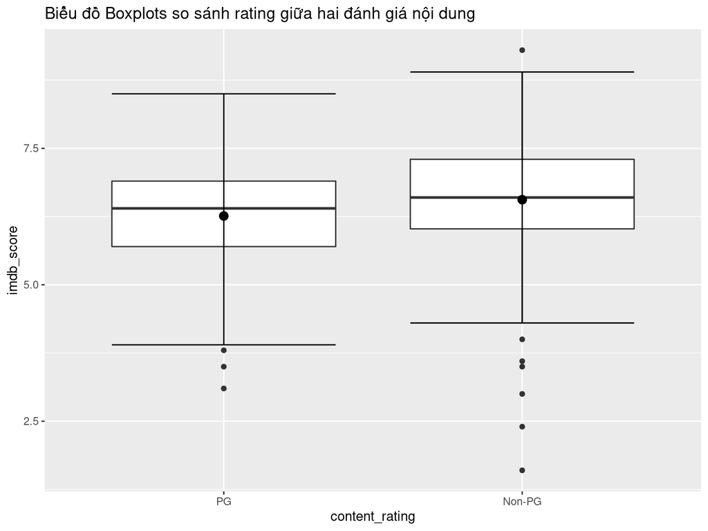

## Phân tích dữ liệu

Câu hỏi 1:

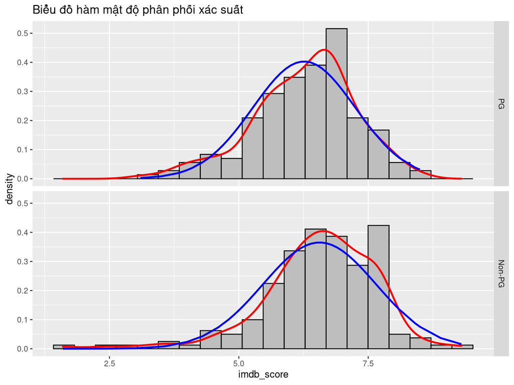

## Phân tích dữ liệu

Câu hỏi 1:

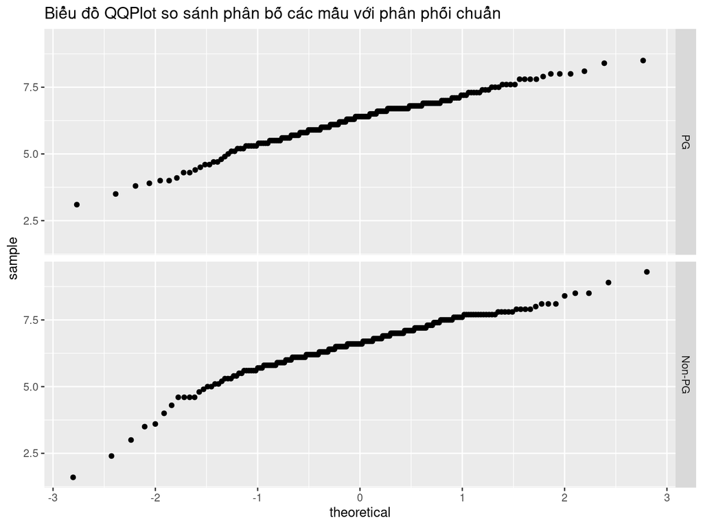

## Phân tích dữ liệu

Câu hỏi 1:

```
## $PG
##    Min. 1st Qu.  Median    Mean 3rd Qu.    Max.
##   3.100   5.700   6.400   6.261   6.900   8.500
##
## $`Non-PG`
##    Min. 1st Qu.  Median    Mean 3rd Qu.    Max.
##   1.600   6.025   6.600   6.559   7.300   9.300
```

## Phân tích dữ liệu:

Câu hỏi 1:

```
## [1] 177
```

```
## [1] 6.261017
```

```
## [1] 198
```

```
## [1] 6.559091
```

```
## [1] -2.771375
```

```
## [1] 0.005861711
```

```
##
##  Welch Two Sample t-test
##
## data:  movie_metadata_sample_copy$imdb_score by movie_metadata_sample_copy$content_rating
## t = -2.7714, df = 372.93, p-value = 0.005862
## alternative hypothesis: true difference in means is not equal to 0
## 95 percent confidence interval:
##  -0.5095633 -0.0865846
## sample estimates:
##     mean in group PG mean in group Non-PG
##             6.261017             6.559091
```

## Phân tích dữ liệu:

Câu hỏi 2:

```
## [1] 356
```

```
## [1] 19
```

```
## $Cantonese
##    Min. 1st Qu.  Median    Mean 3rd Qu.    Max.
##    7.30    7.35    7.40    7.40    7.45    7.50
##
## $Dari
##    Min. 1st Qu.  Median    Mean 3rd Qu.    Max.
##     7.4     7.4     7.4     7.4     7.4     7.4
##
## $English
##    Min. 1st Qu.  Median    Mean 3rd Qu.    Max.
##   1.600   5.800   6.500   6.368   7.000   9.300
##
## $French
##    Min. 1st Qu.  Median    Mean 3rd Qu.    Max.
##    5.80    6.90    6.90    7.02    7.70    7.80
##
## $Hindi
##    Min. 1st Qu.  Median    Mean 3rd Qu.    Max.
##     6.9     6.9     6.9     6.9     6.9     6.9
##
## $Japanese
##    Min. 1st Qu.  Median    Mean 3rd Qu.    Max.
##     7.9     7.9     7.9     7.9     7.9     7.9
##
## $Korean
##    Min. 1st Qu.  Median    Mean 3rd Qu.    Max.
##       7       7       7       7       7       7
##
## $Mandarin
##    Min. 1st Qu.  Median    Mean 3rd Qu.    Max.
##   7.500   7.525   7.550   7.550   7.575   7.600
##
## $Persian
##    Min. 1st Qu.  Median    Mean 3rd Qu.    Max.
##   8.400   8.425   8.450   8.450   8.475   8.500
##
## $Spanish
##    Min. 1st Qu.  Median    Mean 3rd Qu.    Max.
##     6.7     6.9     7.1     7.1     7.3     7.5
##
## $Thai
##    Min. 1st Qu.  Median    Mean 3rd Qu.    Max.
##     7.1     7.1     7.1     7.1     7.1     7.1
##
## $Vietnamese
##    Min. 1st Qu.  Median    Mean 3rd Qu.    Max.
##     7.4     7.4     7.4     7.4     7.4     7.4
```

## Phân tích dữ liệu:

Câu hỏi 2:

Từ đó ta nhận thấy việc kiểm định cho điểm đánh giá phim theo ngôn ngữ là không thể do tập dữ liệu đã thiên vị ngôn ngữ Anh nhiều hơn.

## Phân tích dữ liệu:

Câu hỏi 3:

[figure not shown]

## Phân tích dữ liệu

Câu hỏi 3:

[output not shown]

## Phân tích dữ liệu

Câu hỏi 3:

```
##              Df Sum Sq Mean Sq F value   Pr(>F)
## genres      173  258.9  1.4966   1.915 4.84e-06 ***
## Residuals   201  157.1  0.7816
## ---
## Signif. codes:  0 '***' 0.001 '**' 0.01 '*' 0.05 '.' 0.1 ' ' 1
```

## Phân tích dữ liệu:

Bổ sung: Ngoài những câu hỏi đặt trên, tỷ lệ khung hình là một yếu tố cũng cần được để tâm. Một nghiên cứu để so sánh hiệu quả của phim với tỷ lệ khung hình. Chúng ta sẽ tiến hành thực hiện kiểm định giả thuyết tỷ lệ giữa hai mẫu.

## Phân tích dữ liệu:

So sánh tỷ lệ khung hình theo các thời kỳ:

```
##
##  2-sample test for equality of proportions with continuity correction
##
## data:  fracture out of total
## X-squared = 12.978, df = 1, p-value = 0.0003152
## alternative hypothesis: two.sided
## 95 percent confidence interval:
##  -0.29517994 -0.08650684
## sample estimates:
##    prop 1    prop 2
## 0.4450262 0.6358696
```